```python
from IPython.display import display
from IPython.display import HTML
import IPython.core.display as di # Example: di.display_html('<h3>%s:</h3>' % str, raw=True)

# This line will hide code by default when the notebook is exported as HTML
di.display_html('<script>jQuery(function() {if (jQuery("body.notebook_app").length == 0) { jQuery(".input_area").toggle(); jQuery(".prompt").toggle();}});</script>', raw=True)

# This line will add a button to toggle visibility of code blocks, for use with the HTML export version
di.display_html('''<button onclick="jQuery('.input_area').toggle(); jQuery('.prompt').toggle();">Toggle code</button>''', raw=True)
```

# EdTech Startups - Funding Research (2015-2020)

BY- MANAS BICHOO

```python
import pandas as pd
import numpy as np
import matplotlib.pyplot as plt
import seaborn as sns
color = sns.color_palette()

import plotly.offline as py
py.init_notebook_mode(connected=True)
import plotly.graph_objs as go
%matplotlib inline
from IPython.display import HTML
import re
from pandas import DataFrame as show
```

# Introduction

This case study gives the insights of the funding raised by various Indian startups and how growth changed with several factors. The aim of the study is to get a descriptive overview and a relationship pattern of funding and growth of newly launched startups specifically in EdTech domain. Another important point to understand how funding changes with time is an important aspect. Possible area of interests would be – (Funding ecosystem and time relation, cities as a important factor, which industries, important investors). Dataset we are using contains information of funding of startups from January 2015 to May 2020.The amount invested is in USD. Aggregation of data w.r.t cities, investors, funding type etc. is required to get an optimized result. Here we have done major preprocessing of data and overcome problem of missing data and uncertain distributions. Also, Visualizations are done to find the anomalies and mining patterns from data. It seems to be some cities showing some abnormal behavior when it comes to funding.

A recent survey by NASSCOM on the impact of COVID-19 on Indian startups found that 40 percent of startups have either temporarily shut down operations, or are on the verge of shutting down. [1]

However, the edtech sector has stood its ground during such unprecedented times. With schools and universities shut due to the pandemic-led lockdown, the education system in India has undergone a paradigm shift, with many edtech startups leveraging the situation to their benefit. [1]

India K-12 market stood at 1.53 million in 2018 and is projected to grow at a CAGR of 0.29% to reach 1.55 million by 2024 on account of the increasing number of private schools pursuing high demand for quality education. [2]

India needs an investment of USD 200 billion to address the current need-gap in educational infrastructure. To get a perspective on this amount, one may consider that India’s annual education budget is a mere USD 13 billion, of which almost 80% is spent on meeting the operational expenditure. From this analysis, it is clear that the government alone cannot plug this gap. [3] 735 million users will use online education services in India by 2021. [4]

The  online education market in India wass USD 247 million in 2016 with approximately 1.57 million paid users and is expected to be USD 1.96 billion by 2021 with CAGR 0f 44%[4]

Indian higher education industry is currently valued at USD 19.17 billion and is expected to increase to USD 35.03 billion by 2025 at the rate of 11% CAGR.[8] The FDI in Indian education sector is estimated to be USD 5.85 Bn by 2025 from USD 2.1 billion in 2018.

# EdTech(K-12) Market in India

The global EdTech market is expected to grow at 17% per annum to USD 611 Bn by 2025 led by explosive growth in the Asian region. By the year 2025, the Asian EdTech market, led by India and China, is expected to have 24% share of the global EdTech market. [8]

The Indian EdTech market potential is expected to reach USD 30.8 billion by 2025 with a CAGR of 42.5%. [8]

The EdTech industry spend will reach a global value of USD 252 billion by the year 2020. — TechCrunch India has a population of 572 million people between the ages of 0-24 years (Census of India, 2015). This has led to significant government and private spending in the education sector. The current K-12 school system in India is one of the largest in the world with more than 1.5 million schools that have more than 250 million students.

Almost 50% of students drop out before 5th grade, and 80% by the 8th grade (Gross Enrollment Ratio (GER) in Higher Education, India, 2015). Overall, the outcomes in education are demoralizing: insufficient improvements in basic skills as demonstrated by Pratham’s ASER and PISA reports, delivering unemployable youth, huge dropout rates and lack of progress in encouraging early childhood education.

There is a huge supply-demand gap between the number of students of school going age and number of students enrolled in schools. Out of 360 million children of school going age, only 250 million are enrolled in primary and middle schools. This number drops drastically by the time students reach higher education, with only 28 million students enrolled in higher education and vocational training (Gross Enrollment Ratio (GER) in Higher Education, India, 2015).[5]

The K-12 scenario in India continues to be dominated by government schools, including Madrasas & Unrecognised Schools totalling 1,118,268 during FY17 and accounting for 76.2% of the total schools in India. However, the private schools managed by the trusts, political, religious/ charitable organizations are fast scaling up, aggregating 349,412 during FY17 accounting for 23.8% of the total schools in India (Source: DISE).[6]

The K-12 market is estimated at Rs. 1,655 bn in FY17 and is expected to grow at a CAGR of over 13% over the next three years to reach Rs 2,400 bn, on the back of increasing awareness about the importance of education in the country. Private spend is estimated to account for approximately 90% of the total K-12 market size in FY17, which can be attributed to consistent shifts towards private schools in India. [6]

The K-12 segment is valued at $52 billion with a market share of 52%. With the current enrollment of 260 million, the K-12 segment offers the largest and most attractive segment for digital learning providers in India, the report noted.[10]

By 2027, K-12 Online Education Market is estimated to grow to USD 1803 Billion from USD 450 Billion in 2018 and with a CAGR of about 32.0% during the forecast period.[11]

Indian edtech startups are currently focussing on all fronts — B2B, B2C, B2B-B2C and C2C. The most prominent sub-sectors have been test preparation, online certification, skill development, online discovery, STEAM kits, and enterprise solution among others.[7]

```python
%%HTML
<style type="text/css">
table.dataframe td, table.dataframe th {
    border: 2px  black solid !important;
  color: black !important;
}
</style>
```

```python
data = pd.read_excel('comp2.xlsx')
df.columns
df=data.drop(['Unnamed: 0'], axis = 1)
```

# Sample View Of the Dataset:

```python
df.rename(columns={'Amount in USD':'AmountInUSD',
                          'Investors Name':'Investor',
                          'City  Location':'City',
                   'Industry Vertical':'Industry',
                  'InvestmentnType':'Type',
                  'Startup Name':'Name',
                  'Date dd/mm/yyyy':'Date',
                  'Sr No':'S.No'},
                 inplace=True)


k=df
k[['Name','Type','AmountInUSD','Date','Investor','City']]
```

|  | Name | Type | AmountInUSD | Date | Investor | City |
| --- | --- | --- | --- | --- | --- | --- |
| 0 | Byju’s | Private Equity Round | 2.000000e+08 | 2020-09-01 | Tiger Global Management | Bengaluru |
| 1 | Shuttl | Series C | 8.048394e+06 | 2020-01-13 | Susquehanna Growth Equity | Gurgaon |
| 2 | Mamaearth | Series B | 1.835886e+07 | 2020-09-01 | Sequoia Capital India | Bengaluru |
| 3 | https://www.wealthbucket.in/ | Pre-series A | 3.000000e+06 | 2020-02-01 | Vinod Khatumal | New Delhi |
| 4 | Fashor | Seed Round | 1.800000e+06 | 2020-02-01 | Sprout Venture Partners | Mumbai |
| ... | ... | ... | ... | ... | ... | ... |
| 3093 | WhiteHat Jr | Seed | 1.200000e+06 | 2019-11-04 | Nexus Venture Partners, Omidyar Network | Mumbai |
| 3094 | WhiteHat Jr | Series A | 1.000000e+07 | 2019-11-09 | Nexus Venture Partners, Omidyar Network | Mumbai |
| 3095 | OYO | Series E | 1.000000e+09 | 2018-06-07 | Softbank Vision Fund | New Delhi |
| 3096 | OYO | Series E | 7.500000e+07 | 2019-01-04 | Airbnb | New Delhi |
| 3097 | OYO | Debt Financing | 5.000000e+08 | 2019-01-11 | Mypreffered Transformation | New Delhi |

3098 rows × 6 columns

```python
df['Type'].fillna(method='bfill',inplace=True)#backward filling of null values
```

```python
df.loc[ 192, 'Date'] = '05/07/2018'
df.loc[2571, 'Date'] = '01/07/2015'
df.loc[2606, 'Date'] = '10/07/2015'
df.loc[2775, 'Date'] = '12/05/2015'
df.loc[2776, 'Date'] = '12/05/2015'
df.loc[2831, 'Date'] = '13/04/2015'
df.loc[3011, 'Date'] = '15/01/2015'
df.loc[3029, 'Date'] = '22/01/2015'
date_expand = df['Date'].str.extract(r'(\d{2})/?(\d{2})/?(\d{4})')
df['Year'] = date_expand[2]
df['Month'] = date_expand[1]
df['NewDate'] = date_expand[0]+'/'+date_expand[1]+'/'+date_expand[2]
```

```python
df['Date'] = pd.to_datetime(df['Date'])#['Date']
```

```python
df['City']=df['City'].fillna(value='NotSpecific')
df['Investor']=df['Investor'].fillna(value='Unknown')
```

```python
df['Industry']=df['Industry'].fillna(value='Other')
```

```python
df.loc[df['Industry'].isin(["E-Tech", "Education", "EdTech","EduTech", "Edutech","Edtech","Ed-Tech","Online Education Platform"]), 'Industry'] = 'EdTech'
df.loc[df['Industry'].isin(["ECommerce", "E-Commerce", "E-commerce", "Ecommerce"]), 'Industry'] = 'eCommerce'
df.loc[df['Industry'].isin(["Fin-Tech"]), 'Industry'] = 'FinTech'
```

```python
df.loc[df['Investor'].isin(['Undisclosed investors', 'Undisclosed', 'undisclosed investors', 'Undisclosed Investor', 'Undisclosed investors','Unknown']), 'Investor'] = 'Undisclosed Investors'
df.loc[df['Investor'] == "\\\\xc2\\\\xa0Tiger Global", 'Investor'] = 'Tiger Global'
df.loc[df['Investor'] == "\\\\xc2\\\\xa0IndianIdeas.com", 'Investor'] = 'IndianIdeas'
df.loc[df['Investor'] == "\\\\xc2\\\\xa0IvyCap Ventures, Accel Partners, Dragoneer Investment Group", 'Investor'] = 'IvyCap Ventures, Accel Partners, Dragoneer Investment Group'
df.loc[df['Investor'] == "\\\\xc2\\\\xa0Goldman Sachs", 'Investor'] = 'Goldman Sachs'
```

```python
df.loc[df['AmountInUSD'].isin(['undisclosed', 'unknown', 'Undisclosed']), 'AmountInUSD'] = 'nan'

df['AmountInUSD'] = df['AmountInUSD'].astype(str)
df['AmountInUSD'] = df['AmountInUSD'].apply(lambda x : re.sub("[^0-9]", "", x))
df.loc[df['AmountInUSD']=='', 'AmountInUSD'] = 0 #'nan' # replace with average of funding provided that months
df['AmountInUSD'] = df['AmountInUSD'].astype(float)
```

```python
unique_startup_name=list(df['Name'].unique())
startupname=list(df['Name'])
```

```python
for i in range(len(unique_startup_name)):
    for j in range(len(startupname)):
        if(re.search(unique_startup_name[i],startupname[j])):
            startupname[j]=unique_startup_name[i]
```

```python
df['Name']=startupname
```

```python
df.at[2602,"Name"]= "News Inshorts"
df.at[2602,"Industry"]= "News Application"
df.at[2602,"City"]= "Noida"
df.at[2603,"Name"]= "Bluestone"
df.at[2603,"Industry"]= "Online Jewellery"
df.at[2603,"City"]= "Bangalore"
df.at[2608,"Name"]= "Loyalty Rewards"
df.at[2608,"Industry"]= "Premium Rewards"
df.at[2608,"City"]= "Mumbai"
df.at[2610,"Name"]= "Mamagoto"
df.at[2610,"Industry"]= "Restaurant Chain"
df.at[2610,"City"]= "New Delhi"
df.at[2648,"Name"]= "Flipkart"
df.at[748,"Name"]= "Ola Cabs"
df.at[791,"Name"]= "Ola Cabs"
df.at[924,"Name"]= "Ola Cabs"
df.at[2244,"Name"]= "Ola Cabs"
```

```python
top_20 =show(df.nlargest(20, 'AmountInUSD'))
max_funded_amount = top_10['AmountInUSD'].max()
top_funded = top_10[top_10.AmountInUSD == max_funded_amount]
top_startup_name = top_funded.loc[:,'Name']
```

# Top-20 Fundings from 2015-2020:

These are the top-20 funding amounts raised by different startups/firms in India:

```python
top_20[['Name','Industry','Type','City','AmountInUSD']]
```

|  | Name | Industry | Type | City | AmountInUSD |
| --- | --- | --- | --- | --- | --- |
| 60 | Rapido | Transportation | Series B | Bengaluru | 3.900000e+09 |
| 651 | Flipkart | eCommerce | Private Equity | Bangalore | 2.500000e+09 |
| 2602 | News Inshorts | News Application | Private Equity | Noida | 2.020000e+09 |
| 2608 | Loyalty Rewards | Premium Rewards | Private Equity | Mumbai | 2.019350e+09 |
| 2603 | Bluestone | Online Jewellery | Private Equity | Bangalore | 2.016200e+09 |
| 2610 | Mamagoto | Restaurant Chain | Private Equity | New Delhi | 2.010000e+09 |
| 83 | Pratilipi | Digital Media | Series B | Bengaluru | 1.510950e+09 |
| 830 | Paytm | eCommerce | Private Equity | Bangalore | 1.400000e+09 |
| 966 | Flipkart | eCommerce | Private Equity | Bangalore | 1.400000e+09 |
| 31 | Paytm | FinTech | Funding Round | Noida | 1.000000e+09 |
| 3095 | OYO | Hospitality | Series E | New Delhi | 1.000000e+09 |
| 2648 | Flipkart | Online Marketplace | Private Equity | Bangalore | 7.000000e+08 |
| 2459 | Paytm | E-Commerce & M-Commerce platform | Private Equity | New Delhi | 6.800000e+08 |
| 188 | True North | Finance | Private Equity | Mumbai | 6.000000e+08 |
| 33 | Udaan | B2B | Series D | Bengaluru | 5.850000e+08 |
| 2244 | Ola Cabs | Car Aggregator & Retail Mobile App | Private Equity | Bangalore | 5.000000e+08 |
| 2470 | Snapdeal | Ecommerce Marketplace | Private Equity | New Delhi | 5.000000e+08 |
| 3097 | OYO | Hospitality | Debt Financing | New Delhi | 5.000000e+08 |
| 76 | FabHotels | eCommerce | Series A | Gurgaon | 4.889976e+08 |
| 42 | GOQii | Health and Wellness | Series C | Menlo Park | 4.500000e+08 |

# Oyo's Funding Rounds:

Here displaying some of the funding rounds raised by OYO:

```python
k=df[df['Name']=='OYO']
k[['Name','Type','AmountInUSD']]
```

|  | Name | Type | AmountInUSD |
| --- | --- | --- | --- |
| 115 | OYO | Equity | 1.000000e+08 |
| 586 | OYO | Private Equity | 2.500000e+08 |
| 600 | OYO | Private Equity | 1.000000e+07 |
| 906 | OYO | Private Equity | 2.500000e+08 |
| 1446 | OYO | Private Equity | 6.200000e+07 |
| 1760 | OYO | Private Equity | 1.000000e+08 |
| 1790 | OYO | Seed Funding | 0.000000e+00 |
| 2476 | OYO | Private Equity | 1.000000e+08 |
| 2618 | OYO | Private Equity | 1.000000e+08 |
| 2919 | OYO | Private Equity | 2.500000e+07 |
| 3095 | OYO | Series E | 1.000000e+09 |
| 3096 | OYO | Series E | 7.500000e+07 |
| 3097 | OYO | Debt Financing | 5.000000e+08 |

# Number of fundings per year:

Year-wise Number of fundings raised by startups in India from 2015:

```python
funding_count_yr = pd.DataFrame(df['Year'].value_counts())
funding_count_yr.rename(columns={"Year":"Number of Fundings"}, inplace=True)
funding_count_yr
```

|  | Number of Fundings |
| --- | --- |
| 2016 | 993 |
| 2015 | 936 |
| 2017 | 687 |
| 2018 | 311 |
| 2019 | 115 |
| 2020 | 56 |

```
Number of funding per year in decreasing order(Top 10)
 2016    993
2015    936
2017    687
2018    311
2019    115
2020     56
Name: Year, dtype: int64
```

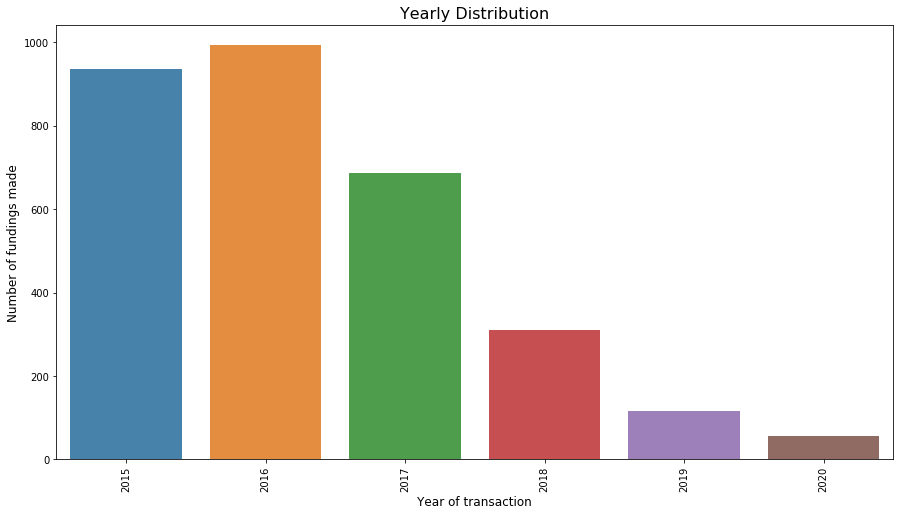

```python
temp = df['Year'].value_counts().sort_values(ascending = False).head(10)
print("Number of funding per year in decreasing order(Top 10)\n",temp)
year = df['Year'].value_counts()
plt.figure(figsize=(15,8))
sns.barplot(year.index, year.values, alpha=0.9)
plt.xticks(rotation='vertical')
plt.xlabel('Year of transaction', fontsize=12)
plt.ylabel('Number of fundings made', fontsize=12)
plt.title("Yearly Distribution", fontsize=16)
plt.show()
```

# Total Funding Amount per year (2015-2020)

Here's a table showing total amout in US Dollars invested by different investors in Indian startups every year:

```python
funding_total_yr = pd.DataFrame(df.groupby(by=['Year'])['AmountInUSD'].sum())
funding_total_yr.rename(columns={"AmountInUSD":"Total Funding(USD-Bn)"}, inplace=True)
funding_total_yr = funding_total_yr.sort_values(by='Total Funding(USD-Bn)', ascending=False)
funding_total_yr
```

| Year | Total Funding(USD-Bn) |
| --- | --- |
| 2015 | 1.691302e+10 |
| 2019 | 1.253823e+10 |
| 2017 | 1.042931e+10 |
| 2018 | 6.122368e+09 |
| 2016 | 3.828089e+09 |
| 2020 | 1.255632e+09 |

# Number Of Investments in different Cities

Here's a city-wise table showing number of funding rounds raised per city:

```python
fundings_count_city = pd.DataFrame(df['City'].value_counts().sort_values(ascending=False)[:10])
fundings_count_city.rename(columns={'City':'Number of Fundings by City'}, inplace=True)
fundings_count_city.head(10)
```

|  | Number of Fundings by City |
| --- | --- |
| Bangalore | 706 |
| Mumbai | 580 |
| New Delhi | 430 |
| Gurgaon | 288 |
| NotSpecific | 180 |
| Bengaluru | 148 |
| Pune | 108 |
| Hyderabad | 101 |
| Chennai | 99 |
| Noida | 95 |

```
Bangalore      706
Mumbai         580
New Delhi      430
Gurgaon        288
NotSpecific    180
Bengaluru      148
Pune           108
Hyderabad      101
Chennai         99
Noida           95
Name: City, dtype: int64
```

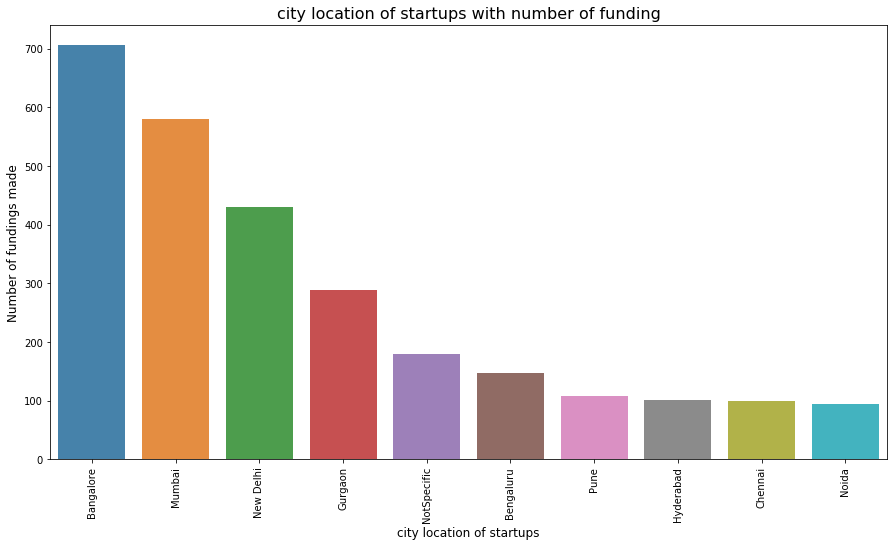

```python
city = df['City'].value_counts().head(10)
print(city)
plt.figure(figsize=(15,8))
sns.barplot(city.index, city.values, alpha=0.9)
plt.xticks(rotation='vertical')
plt.xlabel('city location of startups', fontsize=12)
plt.ylabel('Number of fundings made', fontsize=12)
plt.title("city location of startups with number of funding", fontsize=16)
plt.show()
```

# Number Of Funding Rounds raised in differnt domains/industries:

Here's a table displaying Industry-wise funding rounds raised from 2015:

```python
fundings_count_industry = pd.DataFrame(df['Industry'].value_counts().sort_values(ascending=False))[:15]
fundings_count_industry.rename(columns={'Industry':'Number of Fundings by Industry'}, inplace=True)
fundings_count_industry.head(10)
```

|  | Number of Fundings by Industry |
| --- | --- |
| Consumer Internet | 941 |
| Technology | 478 |
| eCommerce | 307 |
| Other | 171 |
| Healthcare | 71 |
| EdTech | 64 |
| Finance | 64 |
| Logistics | 32 |
| Food & Beverage | 23 |
| FinTech | 16 |

```
Consumer Internet    941
Technology           478
eCommerce            307
Other                171
Healthcare            71
EdTech                64
Finance               64
Logistics             32
Food & Beverage       23
FinTech               16
Name: Industry, dtype: int64
```

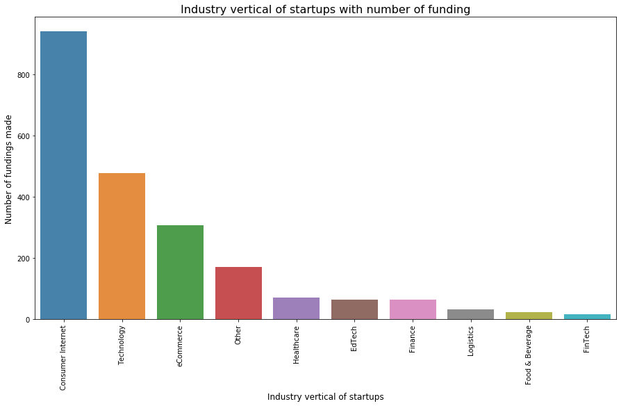

```python
industry = df['Industry'].value_counts().head(10)
print(industry)
plt.figure(figsize=(15,8))
sns.barplot(industry.index, industry.values, alpha=0.9)
plt.xticks(rotation='vertical')
plt.xlabel('Industry vertical of startups', fontsize=12)
plt.ylabel('Number of fundings made', fontsize=12)
plt.title("Industry vertical of startups with number of funding", fontsize=16)
plt.show()
```

# Table Of Most Active Investors/VC's

```python
funding_count_investor = pd.DataFrame(df['Investor'].value_counts()).sort_values(by='Investor', ascending=False)[:10]
funding_count_investor.rename(columns={'Investor': 'Number of Investments by Investor'}, inplace=True)
funding_count_investor.drop(funding_count_investor[funding_count_investor.index == 'Undisclosed Investors'].index, inplace=True)
funding_count_investor.drop(funding_count_investor[funding_count_investor.index == 'Undisclosed investors'].index, inplace=True)
funding_count_investor.head(10)
```

|  | Number of Investments by Investor |
| --- | --- |
| Ratan Tata | 25 |
| Indian Angel Network | 23 |
| Kalaari Capital | 16 |
| Group of Angel Investors | 15 |
| Sequoia Capital | 15 |
| Accel Partners | 13 |
| Venture Catalysts | 11 |
| Brand Capital | 11 |
| RoundGlass Partners | 10 |

# Total Amount Of Money Invested by Top Investors:

```python
funding_total_investor = pd.DataFrame(df.groupby(['Investor'])['AmountInUSD'].sum()).sort_values(by="AmountInUSD", ascending=False)[:15]
funding_total_investor.rename(columns={'AmountInUSD':'Funding by Investor(USD-Bn)'}, inplace=True)
funding_total_investor.head(5)
```

| Investor | Funding by Investor(USD-Bn) |
| --- | --- |
| Westbridge Capital | 3.900000e+09 |
| Softbank | 2.500000e+09 |
| Tiger Global | 2.130500e+09 |
| Goldman Sachs | 2.035000e+09 |
| IndianIdeas | 2.019350e+09 |

# Number of Funding Rounds raised by some of the Top startups in India:

```python
funding_count_company = pd.DataFrame(df['Name'].value_counts()).sort_values(by='Name', ascending=False)[:15]
funding_count_company.rename(columns={'Name': 'Number of Investments by Investor'}, inplace=True)
funding_count_company.head(10)
```

|  | Number of Investments by Investor |
| --- | --- |
| OYO | 13 |
| Ola | 11 |
| Healthi | 11 |
| Swiggy | 9 |
| Paytm | 8 |
| Nykaa | 8 |
| UrbanClap | 7 |
| Digit | 7 |
| Meesho | 6 |
| 1mg | 6 |

# Table Of Total Funding Raised by different Startups:

```python
funding_total_company = pd.DataFrame(df.groupby('Name')['AmountInUSD'].sum()).sort_values(by='AmountInUSD', ascending=False)[:15]
funding_total_company.rename(columns={'AmountInUSD': "Total amount Raised by Startup (USD-Bn)"}, inplace=True)
funding_total_company.head(10)
```

| Name | Total amount Raised by Startup (USD-Bn) |
| --- | --- |
| Flipkart | 4.759700e+09 |
| Rapido | 3.900751e+09 |
| Paytm | 3.348950e+09 |
| OYO | 2.572000e+09 |
| News Inshorts | 2.020000e+09 |
| Loyalty Rewards | 2.019350e+09 |
| Bluestone | 2.016200e+09 |
| Mamagoto | 2.010000e+09 |
| Pratilipi | 1.515250e+09 |
| Ola | 1.070700e+09 |

# EdTech Startups (2015-2020)

Now Let us come back to our case study, EdTech startups that have raised various funding rounds from 2015.

A Sample set from our dataset:

```python
df1=df[(df['Industry']=='EdTech')]
df1.head(50)
```

|  | S.No | Date | Name | Industry | SubVertical | City | Investor | Type | AmountInUSD | Year | Month | NewDate |
| --- | --- | --- | --- | --- | --- | --- | --- | --- | --- | --- | --- | --- |
| 0 | 1 | 2020-09-01 | Byju’s | EdTech | E-learning | Bengaluru | Tiger Global Management | Private Equity Round | 200000000.0 | 2020 | 01 | 09/01/2020 |
| 19 | 20 | 2019-11-13 | Sunstone Eduversity Pvt. Ltd | EdTech | Elearning | Gurgaon | Prime Venture Partners, LetsVenture, PS1 Ventu... | Seed | 1500000.0 | 2019 | 11 | 13/11/2019 |
| 30 | 31 | 2019-11-19 | Furtados School of Music | EdTech | Music Education | Tulangan | IAN Fund and DSG Consumer Partners | Funding Round | 200000000.0 | 2019 | 11 | 19/11/2019 |
| 57 | 58 | 2019-08-23 | AdmitKard | EdTech | University Admissions | Noida | Growth DNA | Seed Round | 1000000.0 | 2019 | 08 | 23/08/2019 |
| 67 | 68 | 2019-10-07 | Byju's | EdTech | Education | Bengaluru | Qatar Investment Authority | Private Equity Round | 150000000.0 | 2019 | 07 | 10/07/2019 |
| 73 | 74 | 2019-08-07 | Board Infinity | EdTech | Full-stack career platform | Chembur | Multiple Angel Investors | Angel Round | 319605.0 | 2019 | 07 | 08/07/2019 |
| 104 | 105 | 2019-10-04 | Toppr | EdTech | E-learning | Mumbai | Milestone | Debt and Preference capital | 6320820.0 | 2019 | 04 | 10/04/2019 |
| 106 | 107 | 2019-10-04 | Unacademy | EdTech | E-learning | Bengaluru | Kalyan Krishnamurthy | Seed/ Angel Funding | 307000.0 | 2019 | 04 | 10/04/2019 |
| 137 | 138 | 2018-11-21 | Genius Corner | EdTech | Personalized Learning | Noida | Individual investors | Seed Funding | 278000.0 | 2018 | 11 | 21/11/2018 |
| 174 | 175 | 2018-09-08 | quizizz | EdTech | e-learning Platform | Bengaluru | Nexus Venture Partners, Prime Venture Partners... | Seed/ Angel Funding | 3000000.0 | 2018 | 08 | 09/08/2018 |
| 213 | 214 | 2018-07-24 | kidovators | EdTech | Skill Learning Platform | Bengaluru | Gray Matters | Seed/ Angel Funding | 180000.0 | 2018 | 07 | 24/07/2018 |
| 244 | 245 | 2018-06-19 | Chrysalis | EdTech | Education Services Provider | Pune | Menterra Venture & Artha Initiatives | Seed/ Angel Funding | 0.0 | 2018 | 06 | 19/06/2018 |
| 255 | 256 | 2018-06-28 | Edureka | EdTech | Online Education Platform | Bengaluru | Leo Capital | Seed/ Angel Funding | 2000000.0 | 2018 | 06 | 28/06/2018 |
| 285 | 286 | 2018-05-04 | IndigoLearn | EdTech | Online Education Platform | Hyderabad | Maheshwar Peri, founder and chairman of career... | Seed / Angel Funding | 150000.0 | 2018 | 04 | 05/04/2018 |
| 286 | 287 | 2018-05-04 | Vedantu | EdTech | Interactive Online Tutoring Platform | Bangalore | Accel Partners, Tiger Global And Others | Private Equity | 10000000.0 | 2018 | 04 | 05/04/2018 |
| 290 | 291 | 2018-09-04 | Kriger Campus | EdTech | Mobile-Based Education Network | Delhi | Undisclosed Investors | Seed / Angel Funding | 46140.0 | 2018 | 04 | 09/04/2018 |
| 369 | 370 | 2018-02-13 | IMAX Program | EdTech | Individualised Progressive Learning Program | Bengaluru | Michael & Susan Dell Foundation, LGT Impact Ve... | Private Equity | 13500000.0 | 2018 | 02 | 13/02/2018 |
| 370 | 371 | 2018-02-14 | Little | EdTech | Online Education Platform | Chennai | Kalpavriksh | Private Equity | 3000000.0 | 2018 | 02 | 14/02/2018 |
| 371 | 372 | 2018-02-14 | Toppr | EdTech | Online Education Platform | Mumbai | Axis Capital Partners | Private Equity | 100000.0 | 2018 | 02 | 14/02/2018 |
| 372 | 373 | 2018-02-14 | Shirsa Labs | EdTech | Integrated Kids Engagement Company | Mumbai | Dewang Neralla, Mahesh Kothurkar,Atul Agarwal | Private Equity | 500000.0 | 2018 | 02 | 14/02/2018 |
| 384 | 385 | 2018-02-26 | Avishkaar Box | EdTech | Education | Delhi | Auxano Deals | Private Equity | 772500.0 | 2018 | 02 | 26/02/2018 |
| 415 | 416 | 2018-01-24 | Rao IIT Academy | EdTech | Coaching Services | Mumbai | Avendus Finance | Structured Debt | 8600000.0 | 2018 | 01 | 24/01/2018 |
| 854 | 855 | 2017-03-04 | Eruditus | EdTech | Executive Education Provider | Mumbai | Bertelsmann India | Private Equity | 8200000.0 | 2017 | 04 | 03/04/2017 |
| 1352 | 1353 | 2016-07-09 | Simplilearn | EdTech | Online Certification programs | Bangalore | InnoVen Capital India | Private Equity | 6000000.0 | 2016 | 09 | 07/09/2016 |
| 1354 | 1355 | 2016-08-09 | TopRankers | EdTech | Online Test Preparation platform | Bangalore | CareerNet Consulting Pvt. Ltd, Ideation Initia... | Seed Funding | 670000.0 | 2016 | 09 | 08/09/2016 |
| 1356 | 1357 | 2016-09-09 | Byju’s | EdTech | Online Learning App | Bangalore | Chan Zuckerberg Initiative, Times Internet Ltd... | Private Equity | 50000000.0 | 2016 | 09 | 09/09/2016 |
| 1474 | 1475 | 2016-08-24 | Convegenius | EdTech | Edutainment platform | Noida | Michael and Susan Dell Foundation | Private Equity | 900000.0 | 2016 | 08 | 24/08/2016 |
| 1574 | 1575 | 2016-07-06 | CueMath | EdTech | K-12 Maths Learning Courses | Bangalore | Sequoia Capital, Unitus Seed Fund | Private Equity | 4000000.0 | 2016 | 06 | 07/06/2016 |
| 1670 | 1671 | 2016-03-05 | Prepathon | EdTech | Competitive Exam learning platform | Mumbai | Blume Ventures | Private Equity | 0.0 | 2016 | 05 | 03/05/2016 |
| 1682 | 1683 | 2016-06-05 | EduAce Services | EdTech | Education Workshops & mentoring programs | Lucknow | MoMagic Technologies | Private Equity | 1000000.0 | 2016 | 05 | 06/05/2016 |
| 1712 | 1713 | 2016-05-18 | Fundamentor | EdTech | Aptitude Development Program | Pune | Subramanya SV | Seed Funding | 0.0 | 2016 | 05 | 18/05/2016 |
| 1713 | 1714 | 2016-05-18 | EduPristine | EdTech | Online Certification Courses | Mumbai | Kaizen Management Advisors, DeVry Inc | Private Equity | 10000000.0 | 2016 | 05 | 18/05/2016 |
| 1756 | 1757 | 2016-08-04 | Vahan | EdTech | Mobile Education Platform | Chennai | Villgro | Seed Funding | 0.0 | 2016 | 04 | 08/04/2016 |
| 1827 | 1828 | 2016-03-03 | Imarticus Learning | EdTech | Financial Services & Analytics Education Insti... | Mumbai | Blinc Advisors, Amit Nanavati, Tashwinder Sing... | Private Equity | 1000000.0 | 2016 | 03 | 03/03/2016 |
| 1916 | 1917 | 2016-05-02 | Magic Crate | EdTech | Children Education Platform | Bangalore | TV Mohandas Pai, Aarin Capital | Seed Funding | 0.0 | 2016 | 02 | 05/02/2016 |
| 1967 | 1968 | 2016-02-17 | Avanti Learning | EdTech | Private Coaching Classes | New Delhi | Michael & Susan Dell Foundation | Private Equity | 5000000.0 | 2016 | 02 | 17/02/2016 |
| 2007 | 2008 | 2016-04-01 | Career360 | EdTech | College Education Portal | New Delhi | MeritTrac | Private Equity | 0.0 | 2016 | 01 | 04/01/2016 |
| 2010 | 2011 | 2016-05-01 | MyChild App | EdTech | Child Disorder Information & Education | Bhopal | Samir Bangara, Anisha Mittal, Amit Gupta, Pall... | Seed Funding | 100000.0 | 2016 | 01 | 05/01/2016 |
| 2019 | 2020 | 2016-06-01 | MyCity4Kids | EdTech | Children Education & Information platform | Gurgaon | SIDBI Venture Capital Limited, YourNest Angel ... | Private Equity | 3000000.0 | 2016 | 01 | 06/01/2016 |
| 2020 | 2021 | 2016-06-01 | Justdakhila.com | EdTech | School Student admissions platform | New Delhi | Ankur Gupta | Seed Funding | 750000.0 | 2016 | 01 | 06/01/2016 |
| 2024 | 2025 | 2016-07-01 | Myly | EdTech | Mobile Based Education platform | Jaipur | Newbie Promoter Pvt Ltd | Seed Funding | 100000.0 | 2016 | 01 | 07/01/2016 |
| 2028 | 2029 | 2016-08-01 | Gyaanzone | EdTech | Career Planning and Education Advisory Platform | Mumbai | GBIM Technologies Pvt Ltd | Seed Funding | 45000.0 | 2016 | 01 | 08/01/2016 |
| 2735 | 2736 | 2015-06-24 | Sigrid Education | EdTech | NaN | Noida | Oliphans Capital | Seed Funding | 0.0 | 2015 | 06 | 24/06/2015 |
| 2766 | 2767 | 2015-07-05 | Toppr | EdTech | NaN | Mumbai | Fidelity Growth Partners India, SAIF Partners,... | Private Equity | 10000000.0 | 2015 | 05 | 07/05/2015 |
| 2767 | 2768 | 2015-07-05 | Vedantu | EdTech | NaN | Bangalore | Accel Partners, Tiger Global Management | Private Equity | 5000000.0 | 2015 | 05 | 07/05/2015 |
| 2769 | 2770 | 2015-08-05 | KleverKid | EdTech | NaN | New Delhi | Aarin Capital Partners | Seed Funding | 0.0 | 2015 | 05 | 08/05/2015 |
| 2776 | 2777 | 2015-12-05 | Plancess | EdTech | NaN | Mumbai | Rajendra Gogri,\\xc2\\xa0 Chandrakant Gogri | Seed Funding | 2000000.0 | 2015 | 05 | 12/05/2015 |
| 2825 | 2826 | 2015-09-04 | Purple Squirrel | EdTech | NaN | Mumbai | Matrix Partners India, India Quotient | Private Equity | 0.0 | 2015 | 04 | 09/04/2015 |
| 2830 | 2831 | 2015-04-13 | Nayi Disha | EdTech | NaN | New Delhi | Ajay Relan, | Seed Funding | 300000.0 | 2015 | 04 | 13/04/2015 |
| 3047 | 3048 | 2020-01-31 | DoubtNut | EdTech | Online Tutoring | Gurugram | Tencent Holdings | Series A | 15000000.0 | 2020 | 01 | 31/01/2020 |

# Average Funding in EdTech

This table displays that the average funding raised by EdTech startups in India amounts to $14116001 including all rounds of funding from pre-seed to Equity Rounds:

```python
show(df1.describe()['AmountInUSD'].astype(int))
```

|  | AmountInUSD |
| --- | --- |
| count | 64 |
| mean | 14116001 |
| std | 41020661 |
| min | 0 |
| 25% | 172500 |
| 50% | 1100000 |
| 75% | 7675000 |
| max | 200000000 |

```python
df1.at[67,"Name"]= "Byju\'s"
df1.at[1356,"Name"]= "Byju\'s"
df1.at[0,"Name"]= "Byju\'s"
```

# EdTech Startups Scenario in 2020:

A recent survey by NASSCOM on the impact of COVID-19 on Indian startups found that 40 percent of startups have either temporarily shut down operations, or are on the verge of shutting down.

However, the edtech sector has stood its ground during such unprecedented times. With schools and universities shut due to the pandemic-led lockdown, the education system in India has undergone a paradigm shift, with many edtech startups leveraging the situation to their benefit.

India K-12 market stood at 1.53 million in 2018 and is projected to grow at a CAGR of 0.29% to reach 1.55 million by 2024 on account of the increasing number of private schools pursuing high demand for quality education.

735 million users will use online education services in India by 2021.

The  online education market in India wass USD 247 million in 2016 with approximately 1.57 million paid users and is expected to be USD 1.96 billion by 2021 with CAGR 0f 44%

The FDI in Indian education sector is estimated to be USD 5.85 Bn by 2025 from USD 2.1 billion in 2018.

India has a population of 572 million people between the ages of 0-24 years (Census of India, 2015). This has led to significant government and private spending in the education sector.

Almost 50% of students drop out before 5th grade, and 80% by the 8th grade (Gross Enrollment Ratio (GER) in Higher Education, India, 2015). Overall, the outcomes in education are demoralizing: insufficient improvements in basic skills as demonstrated by Pratham’s ASER and PISA reports, delivering unemployable youth, huge dropout rates and lack of progress in encouraging early childhood education.

There is a huge supply-demand gap between the number of students of school going age and number of students enrolled in schools. Out of 360 million children of school going age, only 250 million are enrolled in primary and middle schools. This number drops drastically by the time students reach higher education, with only 28 million students enrolled in higher education and vocational training (Gross Enrollment Ratio (GER) in Higher Education, India, 2015).

The K-12 segment is valued at $52 billion with a market share of 52%. With the current enrollment of 260 million, the K-12 segment offers the largest and most attractive segment for digital learning providers in India, the report noted.

By 2027, K-12 Online Education Market is estimated to grow to USD 1803 Billion from USD 450 Billion in 2018 and with a CAGR of about 32.0% during the forecast period.

# Funding in EdTech in 2020(Jan-May)

Here's the table displaying funding raised by EdTech startups in 2020:

```python
x=df1[df1['Year']=='2020']
x[['Date','Name','Industry','City','Investor','Type','AmountInUSD']]
```

|  | Date | Name | Industry | City | Investor | Type | AmountInUSD |
| --- | --- | --- | --- | --- | --- | --- | --- |
| 0 | 2020-09-01 | Byju's | EdTech | Bengaluru | Tiger Global Management | Private Equity Round | 200000000.0 |
| 3047 | 2020-01-31 | DoubtNut | EdTech | Gurugram | Tencent Holdings | Series A | 15000000.0 |
| 3049 | 2020-03-02 | Embibe | EdTech | Mumbai | Reliance Industries Limited (RIL) | Venture Series | 12625020.0 |
| 3055 | 2020-05-02 | WizKlub | EdTech | Bangalore | Incubate Fund India and Insitor Impact Asia Fund | Seed | 1000000.0 |
| 3060 | 2020-02-19 | Unacademy | EdTech | Bangalore | General Atlantic, Sequoia Capital India, and F... | Series D | 110000000.0 |
| 3064 | 2020-03-13 | CollegeKhabri | EdTech | Bhopal | Vdiec Global | Angel | 0.0 |
| 3069 | 2020-09-04 | Vedantu | EdTech | Bengaluru | Legend Capital | Series C1 | 12560000.0 |
| 3083 | 2020-05-05 | Classplus | EdTech | Noida | RTP Global, lume Ventures, Sequoia Capital Ind... | Series A | 9000000.0 |
| 3087 | 2020-02-04 | Guvi | EdTech | Chennai | CBA Capital | Seed | 700000.0 |
| 3088 | 2020-02-04 | Vedantu | EdTech | Bangalore | KB Global | Series C | 6800000.0 |
| 3089 | 2020-02-04 | Pedagogy | EdTech | Ahmedabad | Inflection Point Venture | Seed | 400000.0 |
| 3090 | 2020-02-04 | Camp K-12 | EdTech | Gurugram | SAIF Partners and Matrix | Seed | 4000000.0 |
| 3091 | 2020-02-04 | Lido Learning | EdTech | Mumbai | Picus Capital | Series B | 7500000.0 |
| 3092 | 2020-02-03 | Lido Learning | EdTech | Mumbai | BAce Capital | Series B | 3000000.0 |

# Vedantu

Bengaluru-based online edtech startup Vedantu raised 12.56 million dollars (or Rs 96.06 crore) from Chinese venture firm Legend Capital in April. Omidyar's Ohana Holding also participated in the Series C1 round. In the same month, it raised 6.8 million dollars of funding from South Korea-based KB Global Platform Firm. According to the filings with the Registrar of Companies, Vedantu allotted 3,82,235 Series C2 CCPS to KB Global. The premium amount per share is Rs 1,353.29.

```python
k=df[df['Name']=='Vedantu']
k[['Name','Type','AmountInUSD','Date','Investor']]
```

|  | Name | Type | AmountInUSD | Date | Investor |
| --- | --- | --- | --- | --- | --- |
| 286 | Vedantu | Private Equity | 10000000.0 | 2018-05-04 | Accel Partners, Tiger Global And Others |
| 2767 | Vedantu | Private Equity | 5000000.0 | 2015-07-05 | Accel Partners, Tiger Global Management |
| 3069 | Vedantu | Series C1 | 12560000.0 | 2020-09-04 | Legend Capital |
| 3088 | Vedantu | Series C | 6800000.0 | 2020-02-04 | KB Global |

# Unacademy

It is one of the largest online learning platforms in India has faced a data breach and details of 22 million users of Unacademy are reportedly available for sale now. According to security firm Cyble Inc, a hacker is offering the user database, containing 21,909,707 records, for USD 2,000. Cyble Inc added that it has managed to acquire the database and added the user records to its data breach monitoring service which can be used by millions of Unacademy users to determine whether their account was hacked or not.

```python
k=df[df['Name'] == 'Unacademy']
k[['Name','Type','AmountInUSD','Date','Investor']]
```

|  | Name | Type | AmountInUSD | Date | Investor |
| --- | --- | --- | --- | --- | --- |
| 106 | Unacademy | Seed/ Angel Funding | 307000.0 | 2019-10-04 | Kalyan Krishnamurthy |
| 601 | Unacademy | Private Equity | 11500000.0 | 2017-09-13 | Sequoia Capital India, SAIF Partners, Nexus Ve... |
| 1065 | Unacademy | Private Equity | 4500000.0 | 2017-01-14 | Nexus Venture Partners, Blume Ventures |
| 1696 | Unacademy | Seed Funding | 500000.0 | 2016-12-05 | Blume Ventures, Rajan Anandan, Sumit Jain, Apr... |
| 3060 | Unacademy | Series D | 110000000.0 | 2020-02-19 | General Atlantic, Sequoia Capital India, and F... |

# Lido Learning

```python
k=df[df['Name'] == 'Lido Learning']
k[['Name','Type','AmountInUSD','Date','Investor']]
```

|  | Name | Type | AmountInUSD | Date | Investor |
| --- | --- | --- | --- | --- | --- |
| 3091 | Lido Learning | Series B | 7500000.0 | 2020-02-04 | Picus Capital |
| 3092 | Lido Learning | Series B | 3000000.0 | 2020-02-03 | BAce Capital |

# Classplus

B2B edtech startup Classplus, this month, raised 9 million dollars (over Rs 68 crore) in the Series A round led by RTP Global. The round also saw participation from existing investors, including Blume Ventures, Sequoia Capital India's Surge, Spiral Ventures, and Strive.

```python
k=df[df['Name'] == 'Classplus']
k[['Name','Type','AmountInUSD','Date','Investor']]
```

|  | Name | Type | AmountInUSD | Date | Investor |
| --- | --- | --- | --- | --- | --- |
| 3083 | Classplus | Series A | 9000000.0 | 2020-05-05 | RTP Global, lume Ventures, Sequoia Capital Ind... |

# BYJU's

According to a report in TechCrunch, the capital raise is expected to be a part of the recent funding round led by Tiger Global and General Atlantic. BYJU’S had raised 200 Million Dollars from Tiger Global in January this year, followed by an undisclosed amount from General Atlantic in February. In March alone, BYJU’s saw 6 million new students accessing free lessons on its platform. Bengaluru-headquartered Byju’s has an estimated valuation of close to $8 billion.

```python
k=df1[df1['Name'] == 'Byju\'s']
k[['Name','Type','AmountInUSD','Date','Investor']]
```

|  | Name | Type | AmountInUSD | Date | Investor |
| --- | --- | --- | --- | --- | --- |
| 0 | Byju's | Private Equity Round | 200000000.0 | 2020-09-01 | Tiger Global Management |
| 67 | Byju's | Private Equity Round | 150000000.0 | 2019-10-07 | Qatar Investment Authority |
| 1356 | Byju's | Private Equity | 50000000.0 | 2016-09-09 | Chan Zuckerberg Initiative, Times Internet Ltd... |

# WhiteHat Jr

Mumbai-based edtech startup WhiteHat Jr had raised $10 million in Series A funding led by existing investors Nexus Venture Partners and Omidyar Network India in september 2019.

```python
k=df1[df1['Name'] == 'WhiteHat Jr']
k[['Name','Type','AmountInUSD','Date','Investor']]
```

|  | Name | Type | AmountInUSD | Date | Investor |
| --- | --- | --- | --- | --- | --- |
| 3093 | WhiteHat Jr | Seed | 1200000.0 | 2019-11-04 | Nexus Venture Partners, Omidyar Network |
| 3094 | WhiteHat Jr | Series A | 10000000.0 | 2019-11-09 | Nexus Venture Partners, Omidyar Network |

```python
top_10 = df1.nlargest(10, 'AmountInUSD')
max_funded_amount = top_10['AmountInUSD'].max()
top_funded = top_10[top_10.AmountInUSD == max_funded_amount]
top_startup_name = top_funded.loc[:,'Name']
```

# Top-10 Funding Rounds in EdTech:

```python
k=top_10
k[['Name','Type','AmountInUSD','Date','Investor']]
```

|  | Name | Type | AmountInUSD | Date | Investor |
| --- | --- | --- | --- | --- | --- |
| 0 | Byju's | Private Equity Round | 200000000.0 | 2020-09-01 | Tiger Global Management |
| 30 | Furtados School of Music | Funding Round | 200000000.0 | 2019-11-19 | IAN Fund and DSG Consumer Partners |
| 67 | Byju's | Private Equity Round | 150000000.0 | 2019-10-07 | Qatar Investment Authority |
| 3060 | Unacademy | Series D | 110000000.0 | 2020-02-19 | General Atlantic, Sequoia Capital India, and F... |
| 1356 | Byju's | Private Equity | 50000000.0 | 2016-09-09 | Chan Zuckerberg Initiative, Times Internet Ltd... |
| 3047 | DoubtNut | Series A | 15000000.0 | 2020-01-31 | Tencent Holdings |
| 369 | IMAX Program | Private Equity | 13500000.0 | 2018-02-13 | Michael & Susan Dell Foundation, LGT Impact Ve... |
| 3049 | Embibe | Venture Series | 12625020.0 | 2020-03-02 | Reliance Industries Limited (RIL) |
| 3069 | Vedantu | Series C1 | 12560000.0 | 2020-09-04 | Legend Capital |
| 286 | Vedantu | Private Equity | 10000000.0 | 2018-05-04 | Accel Partners, Tiger Global And Others |

# Number Of Fundings in EdTech per Year

```python
funding_count_yr = pd.DataFrame(df1['Year'].value_counts())
funding_count_yr.rename(columns={"Year":"Number of Fundings in EdTech"}, inplace=True)
funding_count_yr
```

|  | Number of Fundings in EdTech |
| --- | --- |
| 2016 | 19 |
| 2020 | 14 |
| 2018 | 14 |
| 2019 | 9 |
| 2015 | 7 |
| 2017 | 1 |

```
Number of funding per year in decreasing order(Top 10)
 2016    19
2018    14
2020    14
2019     9
2015     7
2017     1
Name: Year, dtype: int64
```

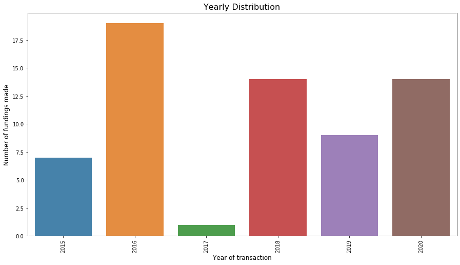

```python
temp = df1['Year'].value_counts().sort_values(ascending = False).head(10)
print("Number of funding per year in decreasing order(Top 10)\n",temp)
year = df1['Year'].value_counts()
plt.figure(figsize=(15,8))
sns.barplot(year.index, year.values, alpha=0.9)
plt.xticks(rotation='vertical')
plt.xlabel('Year of transaction', fontsize=12)
plt.ylabel('Number of fundings made', fontsize=12)
plt.title("Yearly Distribution", fontsize=16)
plt.show()
```

# Total Funding in EdTech per year (2015-2020)

```python
funding_total_yr = pd.DataFrame(df1.groupby(by=['Year'])['AmountInUSD'].sum())
funding_total_yr.rename(columns={"AmountInUSD":"Total Funding(USD-Bn)"}, inplace=True)
funding_total_yr = funding_total_yr.sort_values(by='Total Funding(USD-Bn)', ascending=False)
funding_total_yr
```

| Year | Total Funding(USD-Bn) |
| --- | --- |
| 2020 | 382585020.0 |
| 2019 | 370647425.0 |
| 2016 | 82565000.0 |
| 2018 | 42126640.0 |
| 2015 | 17300000.0 |
| 2017 | 8200000.0 |

# Number Of Fundings in EdTech per city

```python
fundings_count_city = pd.DataFrame(df1['City'].value_counts().sort_values(ascending=False)[:10])
fundings_count_city.rename(columns={'City':'Number of Fundings by City'}, inplace=True)
fundings_count_city.head(10)
```

|  | Number of Fundings by City |
| --- | --- |
| Mumbai | 17 |
| Bangalore | 10 |
| Bengaluru | 8 |
| New Delhi | 5 |
| Noida | 5 |
| Chennai | 3 |
| Pune | 2 |
| Bhopal | 2 |
| Delhi | 2 |
| Gurgaon | 2 |

```
Description count of Location
Mumbai       17
Bangalore    10
Bengaluru     8
New Delhi     5
Noida         5
Name: City, dtype: int64
```

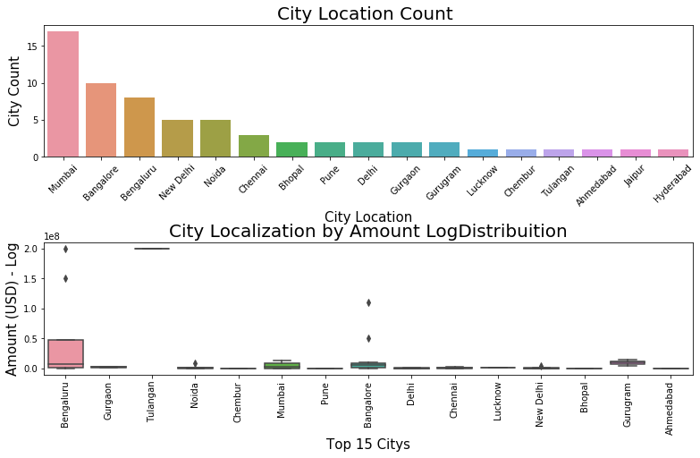

```python
location = df1['City'].value_counts()
print("Description count of Location")
print(location[:5])

plt.figure(figsize=(13,7))

plt.subplot(211)
sns.barplot(x=location.index[:20], y=location.values[:20])
plt.xticks(rotation=45)
plt.xlabel('City Location', fontsize=15)
plt.ylabel('City Count', fontsize=15)
plt.title("City Location Count ", fontsize=20)

plt.subplot(212)
g = sns.boxplot(x='City', y="AmountInUSD",
                data=df1[df1.City.isin(location[:15].index.values)])
g.set_xticklabels(g.get_xticklabels(),rotation=90)
g.set_title("City Localization by Amount LogDistribuition", fontsize=20)
g.set_xlabel("Top 15 Citys", fontsize=15)
g.set_ylabel("Amount (USD) - Log", fontsize=15)

plt.subplots_adjust(hspace = 0.65,top = 0.9)

plt.show()
```

# Top Investors investing in EdTech in 2020

```python
funding_count_investor = pd.DataFrame(x['Investor'].value_counts()).sort_values(by='Investor', ascending=False)[:10]
funding_count_investor.rename(columns={'Investor': 'Number of Investments by Investor'}, inplace=True)
funding_count_investor.drop(funding_count_investor[funding_count_investor.index == 'Undisclosed Investors'].index, inplace=True)
funding_count_investor.drop(funding_count_investor[funding_count_investor.index == 'Undisclosed investors'].index, inplace=True)
funding_count_investor.head(10)
```

|  | Number of Investments by Investor |
| --- | --- |
| Vdiec Global | 1 |
| Picus Capital | 1 |
| SAIF Partners and Matrix | 1 |
| Inflection Point Venture | 1 |
| KB Global | 1 |
| Legend Capital | 1 |
| Tencent Holdings | 1 |
| Incubate Fund India and Insitor Impact Asia Fund | 1 |
| CBA Capital | 1 |
| General Atlantic, Sequoia Capital India, and Facebook | 1 |

# Money Invested by differnt Investors in Edtech in 2020:

```python
funding_total_investor = pd.DataFrame(x.groupby(['Investor'])['AmountInUSD'].sum()).sort_values(by="AmountInUSD", ascending=False)[:15]
funding_total_investor.rename(columns={'AmountInUSD':'Total Funding by Investor(USD-Bn)'}, inplace=True)
funding_total_investor.head(10)
```

| Investor | Total Funding by Investor(USD-Bn) |
| --- | --- |
| Tiger Global Management | 200000000.0 |
| General Atlantic, Sequoia Capital India, and Facebook | 110000000.0 |
| Tencent Holdings | 15000000.0 |
| Reliance Industries Limited (RIL) | 12625020.0 |
| Legend Capital | 12560000.0 |
| RTP Global, lume Ventures, Sequoia Capital India's Surge, Spiral Ventures, and Strive. | 9000000.0 |
| Picus Capital | 7500000.0 |
| KB Global | 6800000.0 |
| SAIF Partners and Matrix | 4000000.0 |
| BAce Capital | 3000000.0 |

# Money Distribution Graph

This graph clearly indicates that in 2020, Investors are investing huge amount of money in EdTech startups

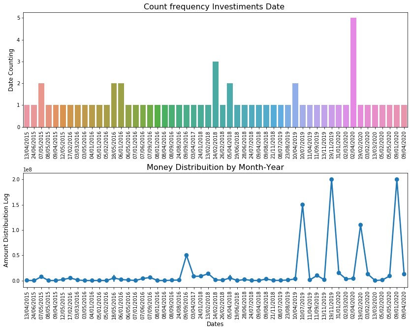

```python
df2 = df1.sort_values(by="Date")
plt.figure(figsize=(14,10))
plt.subplot(211)
sns.countplot(x='NewDate', data=df2)
plt.xticks(rotation=90)
plt.xlabel('', fontsize=12)
plt.ylabel('Date Counting', fontsize=12)
plt.title("Count frequency Investiments Date ", fontsize=16)

plt.subplot(212)
sns.pointplot(x='NewDate', y='AmountInUSD', data=df2)
plt.xticks(rotation=90)
plt.xlabel('Dates', fontsize=12)
plt.ylabel('Amount Distribuition Log', fontsize=12)
plt.title("Money Distribuition by Month-Year", fontsize=16)

plt.subplots_adjust(wspace = 0.2, hspace = 0.4,top = 0.9)

plt.show()
```

# Total Money raised in 2020 by differnt EdTech startups

```python
funding_total_company = pd.DataFrame(x.groupby('Name')['AmountInUSD'].sum()).sort_values(by='AmountInUSD', ascending=False)[:15]
funding_total_company.rename(columns={'AmountInUSD': "Total amount Raised by Startup (USD-Bn)"}, inplace=True)
funding_total_company.head()
```

| Name | Total amount Raised by Startup (USD-Bn) |
| --- | --- |
| Byju's | 200000000.0 |
| Unacademy | 110000000.0 |
| Vedantu | 19360000.0 |
| DoubtNut | 15000000.0 |
| Embibe | 12625020.0 |

```python
funding_count_company = pd.DataFrame(df1['Name'].value_counts()).sort_values(by='Name', ascending=False)[:15]
funding_count_company.rename(columns={'Name': 'Number of Investments by Investor'}, inplace=True)
funding_count_company.head()
```

|  | Number of Investments by Investor |
| --- | --- |
| Vedantu | 4 |
| Toppr | 3 |
| Byju's | 3 |
| WhiteHat Jr | 2 |
| Unacademy | 2 |

# Funding Round Type in 2020

```
Seed                    4
Series A                2
Series B                2
Series D                1
Series C1               1
Venture Series          1
Angel                   1
Private Equity Round    1
Series C                1
Name: Type, dtype: int64
```

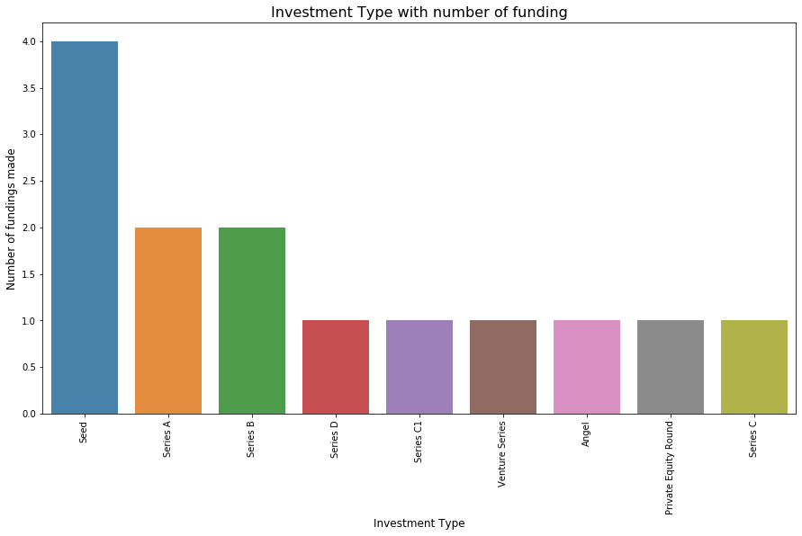

```python
investment = x['Type'].value_counts()
print(investment)
plt.figure(figsize=(15,8))
sns.barplot(investment.index, investment.values, alpha=0.9)
plt.xticks(rotation='vertical')
plt.xlabel('Investment Type', fontsize=12)
plt.ylabel('Number of fundings made', fontsize=12)
plt.title("Investment Type with number of funding", fontsize=16)
plt.show()
```

```python
temp = x["Type"].value_counts()
labels = temp.index
sizes = (temp / temp.sum())*100
trace = go.Pie(labels=labels, values=sizes, hoverinfo='label+percent')
layout = go.Layout(title='Types of investment funding with %')
data = [trace]
fig = go.Figure(data=data, layout=layout)
py.iplot(fig, filename="BorrowerGender")
```

[interactive chart not shown]

# Challenges

Clearly even with enormous funding scale the penetration is limited due to the following factors:

1. Limited govt spending on digital infrastructure or as a whole in education by the government . India ranks a lowly 149th in the world in terms of education spending.
2. Medium of communication / language is an issue as 55–60% of teaching is done in vernacular languages.
3. The Internet is not so blazing fast in tier 2–3 cities where the bulk of students reside.
4. Content taught at schools is very backdated and very limited in engagement to cause curiosity to get built in Kids.

# Revenue Streams

1. Plans for classes start from a mere 2 dollars per subscription to anywhere 50 dollars a month on average . This not only allows them to reach a larger audience but at prices which are very much in range of Individual Per capita in the country
2. Since the growth of internet in the country is unprecedented , access to education is seamlessly solved for as students can now access classes with the click of a button
3. Great Educators on the platform are easily accessible with a schedule which is personalised to the student providing great quality . The outreach of social platforms has also fueled the same .

# How Students Choose EdTech Brands?

[figure not shown]

# Most Active Investors Globally in EdTech:

[figure not shown]

# Sectorwise Division of EdTech Startups

[figure not shown]

# Market Size K-12:

[figure not shown]

# References

[1] https://yourstory.com/2020/05/edtech-startups-raised-coronavirus-funding [2]https://www.techsciresearch.com/report/india-k-12-market/4182.html [3]http://www.technopak.com/Files/India%E2%80%99s_Schooling_Segment_Outlook.pdf [4]https://assets.kpmg/content/dam/kpmg/in/pdf/2017/05/Online-Education-in-India-2021.pdf [5]https://villgro.org/blog/wp-content/uploads/2016/05/Impact-Investing-in-Education-Sector-in-India-V1.0.pdf [6]http://www.careratings.com/upload/NewsFiles/Studies/Overview%20of%20the%20Indian%20Education%20Industry%20June%202018.pdf [7]https://inc42.com/features/the-major-edtech-trends-in-2020-according-to-vcs-in-india/ [8]https://www.asmaindia.in/top-edutech/src/download/top-50-edutech-tools-in-higher-education-2019.pdf [9]https://nfluencepartners.com/wp-content/uploads/2020/02/State-of-the-Market_EdTech-2020.pdf [10]https://www.vccircle.com/here-s-how-demonetisation-disrupting-political-funding-india [11]https://www.openpr.com/news/2008161/huge-growth-in-k-12-online-education-market-growing-at-a-cagr [12]https://inc42.com/features/from-k-12-education-to-test-prep-the-edtech-startups-setting-the-pace-in-india/ [13]https://medium.com/@shravantickoo23/ed-tech-k-12-opportunity-or-saturation-a-pms-perspective-6049fd85ea2b [14]https://inc42.com/buzz/byjus-in-talks-to-raise-400-mn-to-become-second-most-valued-indian-startup/ [15]https://www.fortuneindia.com/bengaluru-buzz/for-edtech-startups-its-raining-money/104233 [16]https://www.forbesindia.com/article/edtech-special/the-huge-investment-opportunity-in-edtech/57733/1